# Tesis

Victor Eduardo Flores García

2026-09-03

##Modelo VECM para identificar la sobrerreacción del tipo de cambio

Basado en el trabajo de Capistrán, Chiquiar y Hernández (2017)

#Bitácora de cambios (revisión)

Los cambios de la revisión se marcan en el código con `# [Rev. 2026-09-15]`. La línea original se conserva comentada debajo de la etiqueta `# Original:`. Respaldo de los archivos originales en `respaldo/`.

**2026-09-15**

1. Paquetes: `install.packages()` sólo instalaba `tibble`; ahora instala `pacman` y `p_load` se encarga del resto.
2. Directorio: se comenta `setwd("~/Documents/TESIS")` para que el Rmd corra desde la carpeta del proyecto; se lee explícitamente la hoja `dts_niv`.
3. X-13ARIMA-SEATS: las series son trimestrales; se declaran con `frequency = 4, start = c(2000, 4)` (antes `frequency = 12, start = c(2000, 9)`).
4. Dinero: CCH (2017) usan M1 **real** (M1/P, Tabla 1). Se define `m` = M1 desestacionalizado / INPC desestacionalizado.
5. Tasas de interés: CCH (2017, pie de página 5) usan `0.25 * ln(1 + R/100)`; faltaba el logaritmo en `r` y `r_usa`.
6. Series de tiempo: se corrige el inicio a `c(2000, 4)`, se excluye la columna `Periodo` y cada objeto `*_ts` se construye con su tibble correspondiente.
7. Tipo de cambio (Excel): la tabla dinámica de la hoja `e` sumaba los tres meses del trimestre; se cambió a promedio y se actualizó la columna `e` de `dts_niv` (ver hoja `bitacora` de `datos.xlsx`). El Rmd no cambia en este punto.

**2026-09-15**

8. Variables dicotómicas (Bloque 1): escalones de CCH (2017, p. 9) `D091`, `D121` y `D151`. `D914` (1991T4) queda fuera de la muestra. Se agregan impulsos `D202` y `D203` por la pandemia (2020T2 y 2020T3), que no existen en CCH; se activan o desactivan con `incluir_covid`.
9. DF-GLS: el chunk “con tendencia” usaba `model = "constant"`; se cambia a `model = "trend"`.
10. Réplica de la Tabla 3 de CCH (Bloque 2): pruebas ADF y DF-GLS en niveles y primeras diferencias con la especificación de CCH (constante y tendencia en niveles con tendencia; sólo constante en tasas y diferencias) y rezagos por el criterio MAIC de Ng y Perron (2001).
11. ARDL (Bloque 3): la demanda de dinero y la relación del producto incluyen las dummies como regresores fijos, como en CCH (2017, Tabla 2).
12. VAR subyacente (Bloque 4): exógenas en primeras diferencias con un rezago (Δwti, Δpp_usa) más las dummies, como en CCH (2017, p. 13); `VARselect` evalúa de 1 a 4 rezagos (Tabla 4) y el VAR se estima con p = 2 y constante, coherente con `ca.jo(K = 2)`.
13. Exogeneidad débil de `y_usa` y `r_usa` (Bloque 4): prueba LR sobre las cargas α en el sistema completo y prueba de la traza del sistema parcial (constante y escalones restringidos al espacio de cointegración) con valores críticos simulados, como en CCH (2017, Tabla 5).
14. Bounds test con constante restringida (`case = 2`), que es la especificación de CCH (2017, Tabla 2, nota), además del `case = 3` original.
15. Comparación de especificaciones de OUT y MD (Bloque 3): con y sin tendencia lineal, elegidas por BIC (CCH, 2017, p. 8), y distintos juegos de dummies (ninguna, pandemia, CCH y fechas de Bai-Perron).
16. Búsqueda exploratoria de cambios estructurales de Bai y Perron (2003) en las relaciones estáticas de OUT y MD; se agrega `strucchange` a `p_load`.

**2026-09-18: datos nuevos de Víctor**

17. Los datos ahora se leen de `datos_v2.xlsx`, que agrega Cetes a 91 días (`cetes91`, clave SF3338) y las series de FRED `cpf3m`, `tb3ms` y `tedrate`.
18. `datos_v2.xlsx` se construyó sobre el archivo original, por lo que se volvió a corregir el tipo de cambio (promedio trimestral, no suma) y se agregó la columna `r91` a `dts_niv` (ver hoja `bitacora`).
19. Tasa de interés doméstica: se usa Cetes a 91 días como en CCH (2017, Tabla 1). Con `usar_cetes91 <- FALSE` se vuelve a Cetes a 28 días.
20. Diferencial de financiamiento: `TEDRATE` se descontinuó en 2021T4, así que se usa `ted = cpf3m - tb3ms` (papel comercial financiero AA a 3 meses menos Cetes del Tesoro a 3 meses), que cubre toda la muestra. Se compara con `tedrate` en el traslape.
21. `ted` entra en primeras diferencias con un rezago como exógena del VAR y del sistema parcial, y se agrega a las pruebas de raíz unitaria (Tabla 3).

**2026-09-19: variables dicotómicas**

22. Pruebas de elasticidad unitaria (Bloque 3): se replican las pruebas de Wald de CCH (2017, pp. 9-10) sobre los coeficientes de largo plazo (p_usa = 1, e = 1, r = 1, r_usa = -1, y = 1, y_usa = 1), calculadas con el método delta.
23. La tabla comparativa de OUT y MD agrega el valor-p de la elasticidad unitaria de cada especificación.
24. Sensibilidad del rango de cointegración a las dummies (Bloque 4): se repite la prueba de la traza del sistema parcial con cinco configuraciones (sin dummies, sólo pandemia, escalones de CCH con y sin pandemia, y escalones de Bai-Perron con pandemia), cada una con sus propios valores críticos simulados.

**2026-09-19: tres escenarios para el VECM–aquí necesito de tu feedback, Víctor: ¿que quieres presentar?**

29. La función de valores críticos por bootstrap se generaliza: recibe la prueba a recalcular y descarta las repeticiones en las que el algoritmo iterativo no converge, informando cuántas fueron válidas.
30. Nuevo Bloque 6: se plantean y estiman **tres escenarios** para el espacio de cointegración (A: sin restricciones; B: sólo UIP y OUT; C: las cuatro relaciones de CCH), con su prueba LR, valores críticos bootstrap, vectores de cointegración, velocidades de ajuste y una guía de decisión. **La elección entre los tres escenarios es tuya, Víctor.**

#Bloque 1: Obtención y transformación de los datos

Importar librerías y datos para el periodo 2000T4-2025T4

```r
# [Rev. 2026-09-15] install.packages() recibía varios paquetes como argumentos separados y sólo instalaba "tibble"
# Original: if (!require("pacman")) install.packages("tibble", "seasonal", "tidyverse", "readxl","readr", "scales", "forecast", "feasts", "tsibble", "xts", "zoo", "ARDL", "urca", "tseries", "vars")
if (!require("pacman")) install.packages("pacman")
# [Rev. 2026-09-15] Se agrega strucchange para la búsqueda de cambios estructurales (Bloque 3)
# Original: pacman::p_load(tibble, seasonal, tidyverse, readxl, readr, scales, forecast, feasts, tsibble, xts, zoo, ARDL, urca, tseries, vars)
pacman::p_load(tibble, seasonal, tidyverse, readxl, readr, scales, forecast, feasts, tsibble, xts, zoo, ARDL, urca, tseries, vars, strucchange)
```

[output not shown]

[output not shown]

[output not shown]

Importar los datos en niveles

```r
# [Rev. 2026-09-15] Se usa la carpeta del proyecto (donde está el Rmd) y se indica la hoja explícitamente
# Original: setwd("~/Documents/TESIS")
# Original: datos<-read_excel("datos.xlsx")
# [Rev. 2026-09-18] Datos nuevos del tesista (Cetes 91 días y series de FRED para el diferencial)
# Original: datos<-read_excel("datos.xlsx", sheet = "dts_niv")
datos<-read_excel("datos_v2.xlsx", sheet = "dts_niv")
```

Tasa de interés doméstica y diferencial de financiamiento

CCH (2017, Tabla 1) usan Cetes a 91 días y el diferencial TED. TEDRATE se descontinuó (termina en 2021T4), por lo que se usa el diferencial entre el papel comercial financiero AA a 3 meses (CPF3M) y los Cetes del Tesoro a 3 meses (TB3MS), disponible para toda la muestra.

```r
# [Rev. 2026-09-18] Nuevo chunk: elección de la tasa doméstica y construcción del diferencial
usar_cetes91 <- TRUE # <- Cambie a FALSE para usar Cetes a 28 días (SF282), como en la versión previa

comparacion_ted <- datos %>%
  dplyr::select(Periodo, tedrate, cpf3m, tb3ms) %>%
  mutate(ted_sustituto = cpf3m - tb3ms)

# Correlación en el traslape con el TED original (hasta 2021T4)
print(comparacion_ted %>%
        filter(!is.na(tedrate)) %>%
        summarise(Correlacion = cor(tedrate, ted_sustituto),
                  Media_TED = mean(tedrate),
                  Media_sustituto = mean(ted_sustituto)))
```

```
## # A tibble: 1 × 3
##   Correlacion Media_TED Media_sustituto
##         <dbl>     <dbl>           <dbl>
## 1       0.964     0.396           0.263
```

```r
datos <- datos %>%
  mutate(
    r = if (usar_cetes91) r91 else r, # Cetes 91 días (SF3338) o 28 días (SF282)
    ted = cpf3m - tb3ms               # Diferencial de financiamiento (sustituto del TED)
  ) %>%
  dplyr::select(-r91, -cpf3m, -tb3ms, -tedrate)

# [Rev. 2026-09-18] En el traslape (2000T4-2021T4) la correlación entre TEDRATE y cpf3m - tb3ms es 0.964
# (medias 0.396 y 0.263), por lo que el sustituto reproduce bien la dinámica del diferencial original.
```

Ajuste estacional mediante X-13 ARIMA SEATS.

Nota: se realiza el ajuste estacional únicamente para estas dos series, ya que el resto ya contaban con este ajuste. Además, CCH(2017) mencionan que, fueron las únicas series que desestacionalizaron mediante la metodología TRAMO-SEATS (ver pp. 6, pie de página 5)

```r
seleccion_ts <- datos %>%
  dplyr::select(c("p", "m")) %>%
  mutate(
    # [Rev. 2026-09-15] Los datos son trimestrales y empiezan en 2000T4
    # Original: p_ts = ts(p, frequency = 12, start = c(2000, 9)),
    # Original: m_ts = ts(m, frequency = 12, start = c(2000, 9))
    p_ts = ts(p, frequency = 4, start = c(2000, 4)),
    m_ts = ts(m, frequency = 4, start = c(2000, 4))
  )

# Ajuste estacional X-13ARIMA-SEATS
p_ae <- seas(seleccion_ts$p_ts)
m_ae <- seas(seleccion_ts$m_ts)

seleccion_ts <- seleccion_ts %>%
  mutate(
    p_ae_num = as.numeric(final(p_ae)),
    m_ae_num = as.numeric(final(m_ae))
  )
```

Obtener un tibble con todas las series numéricas en niveles, el cual se nombrará como “datos”.

```r
datos <- datos %>%
   mutate(
     p = seleccion_ts$p_ae_num,
     # [Rev. 2026-09-15] M1 real desestacionalizado (M1/P), como en CCH (2017, Tabla 1)
     # Original: m = seleccion_ts$m_ae_num
     m = seleccion_ts$m_ae_num / seleccion_ts$p_ae_num
   )
```

Aplicar las transformaciones logarítmicas y obtener todas las series numéricas en logaritmos con el nombre “Ldatos”.

```r
Ldatos <- datos %>%
  mutate(
    y = log(datos$y),
    p = log(seleccion_ts$p_ae_num),
    # [Rev. 2026-09-15] Faltaba el logaritmo: CCH (2017, pie de página 5) usan 0.25 ln(1 + R/100)
    # Original: r = 0.25 * (1 + datos$r/100),
    r = 0.25 * log(1 + datos$r/100),
    # [Rev. 2026-09-15] M1 real (datos$m ya es M1/P desestacionalizado)
    # Original: m = log(seleccion_ts$m_ae_num),
    m = log(datos$m),
    e = log(datos$e),
    y_usa = log(datos$y_usa),
    p_usa = log(datos$p_usa),
    wti = log(datos$wti),
    pp_usa = log(datos$pp_usa),
    # [Rev. 2026-09-15] Faltaba el logaritmo
    # Original: r_usa = 0.25 * (1 + datos$r_usa/100)
    r_usa = 0.25 * log(1 + datos$r_usa/100)
  )
```

Obtener las primeras diferencias de las series en niveles “Ddatos”.

```r
Ddatos <- datos %>%
  mutate(
    y = datos$y - lag(datos$y),
    m = datos$m - lag(datos$m),
    p = datos$p - lag(datos$p),
    r = datos$r - lag(datos$r),
    y_usa = datos$y_usa - lag(datos$y_usa),
    p_usa = datos$p_usa - lag(datos$p_usa),
    r_usa = datos$r_usa - lag(datos$r_usa),
    e = datos$e - lag(datos$e),
    wti = datos$wti - lag(datos$wti),
    pp_usa = datos$pp_usa - lag(datos$pp_usa),
    # [Rev. 2026-09-18] Diferencial de financiamiento
    ted = datos$ted - lag(datos$ted)
         )
```

Obtener las primeras diferencias logarítmicas “DLdatos”.

```r
DLdatos <- Ldatos %>%
  mutate(
    y = Ldatos$y - lag(Ldatos$y),
    m = Ldatos$m - lag(Ldatos$m),
    p = Ldatos$p - lag(Ldatos$p),
    r = Ldatos$r - lag(Ldatos$r),
    y_usa = Ldatos$y_usa - lag(Ldatos$y_usa),
    p_usa = Ldatos$p_usa - lag(Ldatos$p_usa),
    r_usa = Ldatos$r_usa - lag(Ldatos$r_usa),
    e = Ldatos$e - lag(Ldatos$e),
    wti = Ldatos$wti - lag(Ldatos$wti),
    pp_usa = Ldatos$pp_usa - lag(Ldatos$pp_usa),
    # [Rev. 2026-09-18] Diferencial de financiamiento (no se transforma a logaritmos, como en CCH)
    ted = Ldatos$ted - lag(Ldatos$ted)
         )
```

Variables dicotómicas

Nota: CCH (2017, p. 9) usan dummies de escalón. D914 (cambio regulatorio de M1 en 1991T4) queda fuera de la muestra. D091, D121 y D151 se conservan con sus fechas originales. D202 y D203 son impulsos por la pandemia (no están en CCH).

```r
# [Rev. 2026-09-15] Nuevo chunk: dummies de CCH (2017) y de la pandemia
incluir_covid <- TRUE # <- Cambie a FALSE para estimar sin las dummies de la pandemia

dummies <- datos %>%
  dplyr::select(Periodo) %>%
  mutate(
    anio = as.numeric(substr(Periodo, 1, 4)),
    trim = as.numeric(substr(Periodo, 6, 7)),
    D091 = ifelse(anio + (trim - 1)/4 >= 2009, 1, 0), # Escalón desde 2009T1
    D121 = ifelse(anio + (trim - 1)/4 >= 2012, 1, 0), # Escalón desde 2012T1
    D151 = ifelse(anio + (trim - 1)/4 >= 2015, 1, 0), # Escalón desde 2015T1
    D202 = ifelse(Periodo == "2020/02", 1, 0),        # Impulso 2020T2
    D203 = ifelse(Periodo == "2020/03", 1, 0),        # Impulso 2020T3
    # [Rev. 2026-09-19] Escalón permanente desde 2020T2: la pandemia dejó un cambio de nivel (ver diagnóstico del Bloque 3)
    S2002 = ifelse(anio + (trim - 1)/4 >= 2020.25, 1, 0)
  ) %>%
  dplyr::select(-anio, -trim)

dummies_escalon <- c("D091", "D121", "D151")

# [Rev. 2026-09-19] La pandemia se modela con escalón permanente más impulsos
# Original: dummies_covid <- if (incluir_covid) c("D202", "D203") else NULL
pandemia_escalon <- TRUE # <- Cambie a FALSE para usar únicamente los impulsos

dummies_covid <- if (incluir_covid) {
  if (pandemia_escalon) c("S2002", "D202", "D203") else c("D202", "D203")
} else NULL

# El escalón se restringe al espacio de cointegración; los impulsos entran sin restricción
dummies_covid_escalon <- intersect(dummies_covid, "S2002")
dummies_covid_impulso <- intersect(dummies_covid, c("D202", "D203"))
```

Transformar a series de tiempo

```r
# [Rev. 2026-09-15] Inicio en 2000T4, sin la columna de texto "Periodo" y cada objeto con su tibble
# Original: datos_ts <- ts(Ldatos, frequency = 4, start = c(2000, 2))
# Original: Ddatos_ts <- ts(Ldatos, frequency = 4, start = c(2000, 2))
# Original: Ldatos_ts <- ts(Ldatos, frequency = 4, start = c(2000, 2))
# Original: DLdatos_ts <- ts(Ldatos, frequency = 4, start = c(2000, 2))
datos_ts <- ts(datos %>% dplyr::select(-Periodo), frequency = 4, start = c(2000, 4))
Ddatos_ts <- ts(Ddatos %>% dplyr::select(-Periodo), frequency = 4, start = c(2000, 4))
Ldatos_ts <- ts(Ldatos %>% dplyr::select(-Periodo), frequency = 4, start = c(2000, 4))
DLdatos_ts <- ts(DLdatos %>% dplyr::select(-Periodo), frequency = 4, start = c(2000, 4))
```

Graficar las series de interés

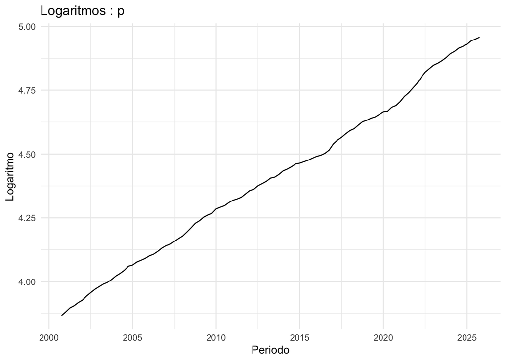

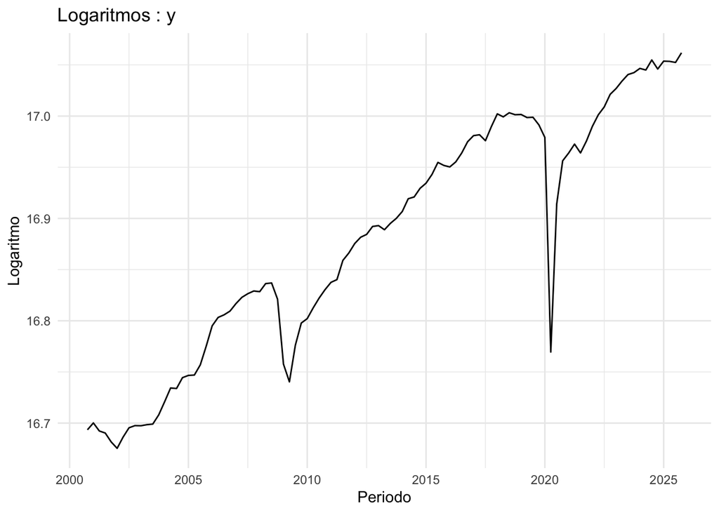

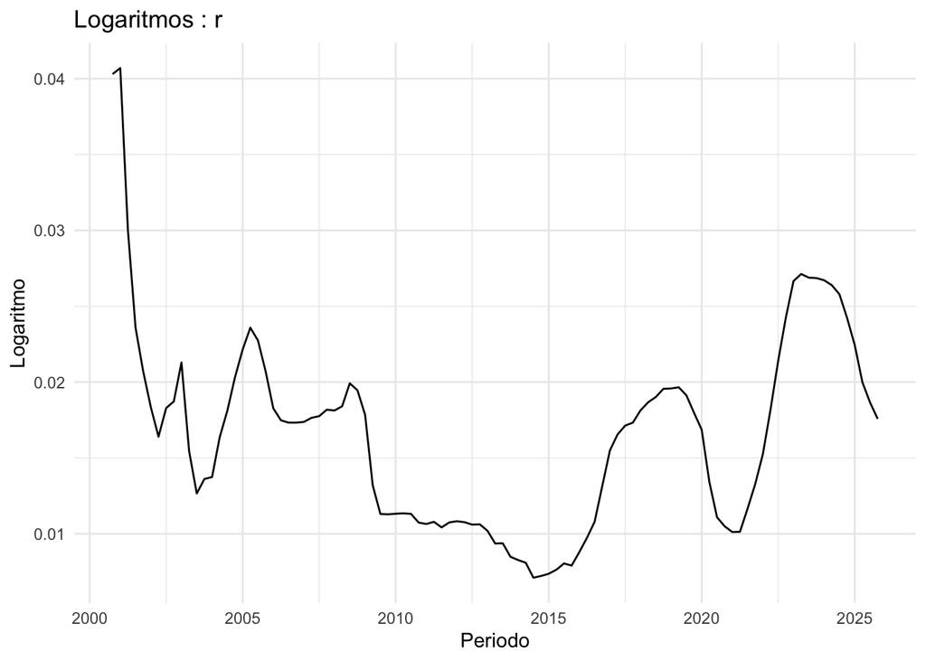

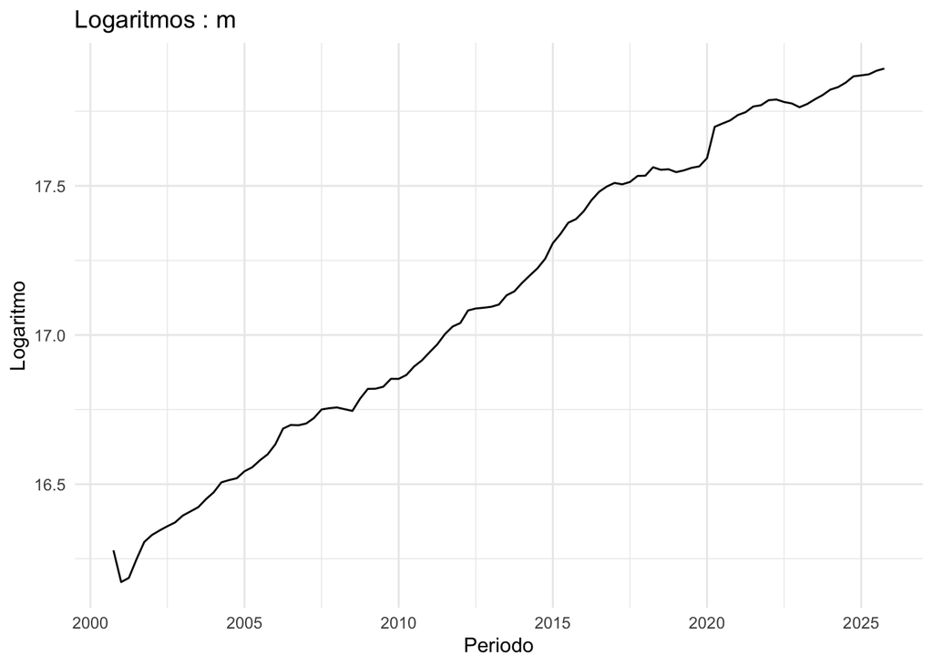

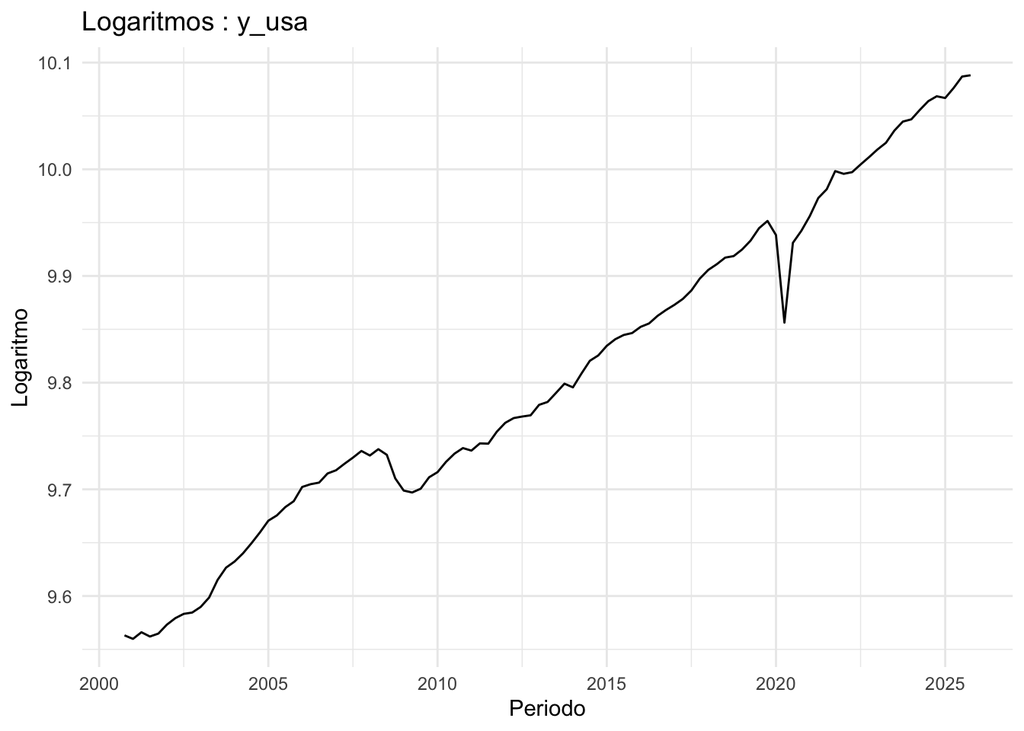

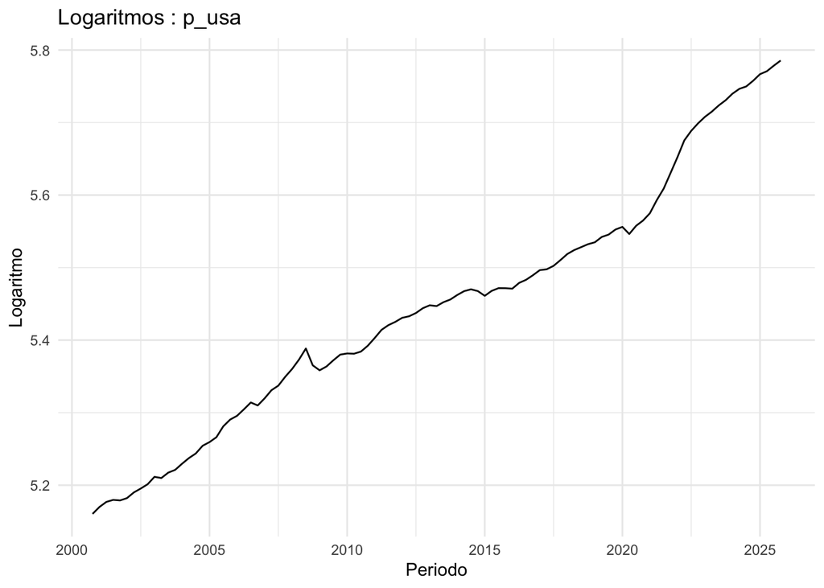

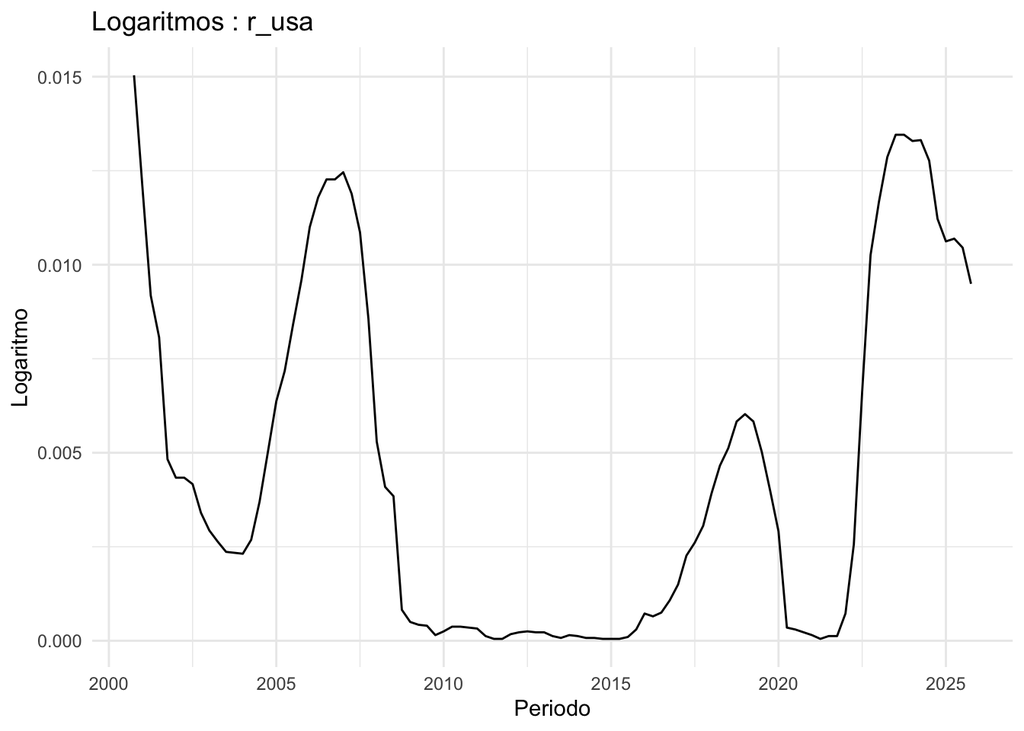

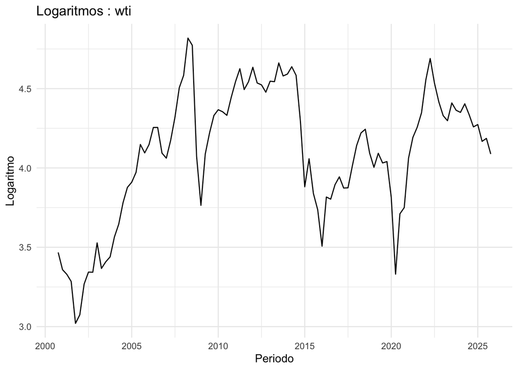

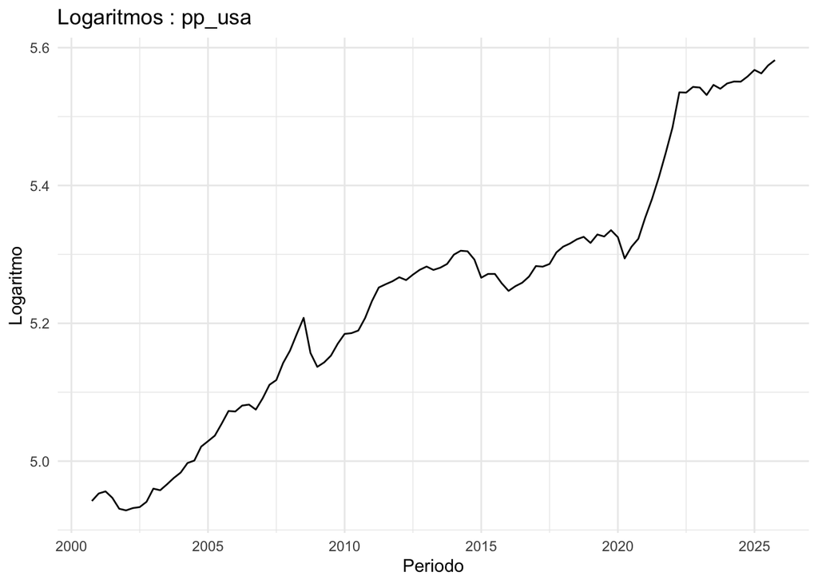

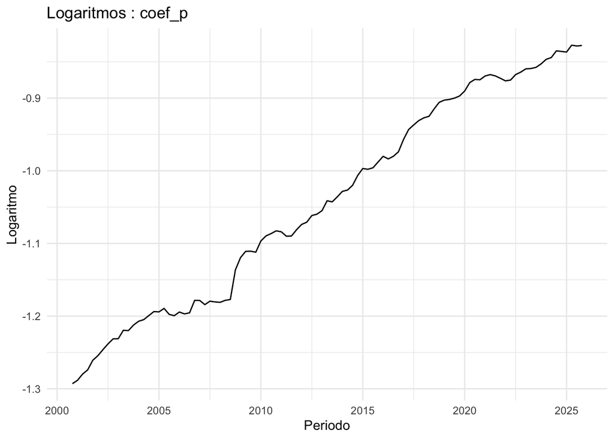

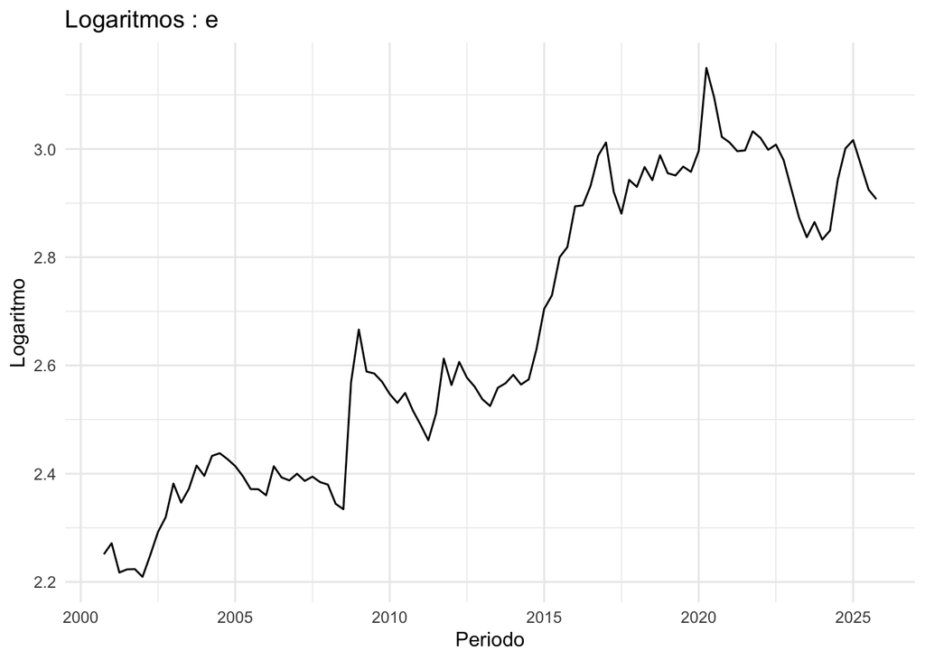

```r
# [Rev. 2026-09-15] Inicio en 2000T4 y sin la columna "Periodo"
# Original: datos_a_graficar <- ts(Ldatos %>% # <- Inserte las series de interés
# Original:       mutate(coef_p = log(datos$p / datos$p_usa)),
# Original:       frequency = 4, start = c(2000, 2)
# Original:       )
datos_a_graficar <- ts(Ldatos %>% # <- Inserte las series de interés
      mutate(coef_p = log(datos$p / datos$p_usa)) %>%
      dplyr::select(-Periodo),
      frequency = 4, start = c(2000, 4)
      )

series_interes <- c("p", "y", "r", "m", "y_usa", "p_usa", "r_usa", "wti", "pp_usa", "coef_p", "e")

for (serie in series_interes) {
  p <- autoplot(datos_a_graficar[, serie]) +
    theme_minimal() +
    labs(
      title = paste("Logaritmos",#<- Modifique según el tipo de datos
                    ":", serie),
      y = "Logaritmo", #<- Modifique según el tipo de datos
      x = "Periodo"
    )
  print(p)
}
```

#Bloque 2: Pruebas de raíces unitarias

Seleccionar alguna de las series NUMÉRICAS para las pruebas

```r
datos_adf <- DLdatos
```

Prueba sin constante ni tendencia

```r
resultados_adf <- datos_adf %>%
  dplyr::select(where(~ is.ts(.x) || inherits(.x, "ts") || is.numeric(.x))) %>%
  map_dfr(function(x) {

    serie <- as.numeric(na.omit(x))

    test <- ur.df(serie, type = "none", selectlags = "AIC")

    tau_stat <- test@teststat[1]
    cv_5pct  <- test@cval[1, "5pct"]

    tibble(
      Estadistico_tau = tau_stat,
      CV_5pct = cv_5pct,
      Lags = test@lags,
      Estacionaria_5pct = ifelse(tau_stat < cv_5pct, "Sí", "No")
    )
  }, .id = "Serie")

print(resultados_adf)
```

```
## # A tibble: 11 × 5
##    Serie  Estadistico_tau CV_5pct  Lags Estacionaria_5pct
##    <chr>            <dbl>   <dbl> <int> <chr>
##  1 y                -8.76   -1.95     1 Sí
##  2 p                -1.60   -1.95     1 No
##  3 r                -6.15   -1.95     1 Sí
##  4 m                -4.18   -1.95     1 Sí
##  5 e                -7.41   -1.95     1 Sí
##  6 y_usa            -6.27   -1.95     1 Sí
##  7 p_usa            -3.11   -1.95     1 Sí
##  8 r_usa            -4.14   -1.95     1 Sí
##  9 wti              -7.15   -1.95     1 Sí
## 10 pp_usa           -4.52   -1.95     1 Sí
## 11 ted              -8.10   -1.95     1 Sí
```

Prueba con constante

```r
resultados_adf <- datos_adf %>%
  dplyr::select(where(~ is.ts(.x) || inherits(.x, "ts") || is.numeric(.x))) %>%
  map_dfr(function(x) {

    serie <- as.numeric(na.omit(x))

    test <- ur.df(serie, type = "drift", selectlags = "AIC")

    tau_stat <- test@teststat[1]
    cv_5pct  <- test@cval[1, "5pct"]

    tibble(
      Estadistico_tau = tau_stat,
      CV_5pct = cv_5pct,
      Lags = test@lags,
      Estacionaria_5pct = ifelse(tau_stat < cv_5pct, "Sí", "No")
    )
  }, .id = "Serie")

print(resultados_adf)
```

```
## # A tibble: 11 × 5
##    Serie  Estadistico_tau CV_5pct  Lags Estacionaria_5pct
##    <chr>            <dbl>   <dbl> <int> <chr>
##  1 y                -9.08   -2.89     1 Sí
##  2 p                -4.94   -2.89     1 Sí
##  3 r                -6.07   -2.89     1 Sí
##  4 m                -7.36   -2.89     1 Sí
##  5 e                -7.61   -2.89     1 Sí
##  6 y_usa            -8.23   -2.89     1 Sí
##  7 p_usa            -5.26   -2.89     1 Sí
##  8 r_usa            -4.11   -2.89     1 Sí
##  9 wti              -7.13   -2.89     1 Sí
## 10 pp_usa           -5.31   -2.89     1 Sí
## 11 ted              -8.06   -2.89     1 Sí
```

Prueba con tendencia

```r
resultados_adf <- datos_adf %>%
  dplyr::select(where(~ is.ts(.x) || inherits(.x, "ts") || is.numeric(.x))) %>%
  map_dfr(function(x) {

    serie <- as.numeric(na.omit(x))

    test <- ur.df(serie, type = "trend", selectlags = "AIC")

    tau_stat <- test@teststat[1]
    cv_5pct  <- test@cval[1, "5pct"]

    tibble(
      Estadistico_tau = tau_stat,
      CV_5pct = cv_5pct,
      Lags = test@lags,
      Estacionaria_5pct = ifelse(tau_stat < cv_5pct, "Sí", "No")
    )
  }, .id = "Serie")

print(resultados_adf)
```

```
## # A tibble: 11 × 5
##    Serie  Estadistico_tau CV_5pct  Lags Estacionaria_5pct
##    <chr>            <dbl>   <dbl> <int> <chr>
##  1 y                -9.03   -3.45     1 Sí
##  2 p                -4.96   -3.45     1 Sí
##  3 r                -5.83   -3.45     1 Sí
##  4 m                -7.66   -3.45     1 Sí
##  5 e                -7.63   -3.45     1 Sí
##  6 y_usa            -8.22   -3.45     1 Sí
##  7 p_usa            -5.38   -3.45     1 Sí
##  8 r_usa            -3.96   -3.45     1 Sí
##  9 wti              -7.17   -3.45     1 Sí
## 10 pp_usa           -5.30   -3.45     1 Sí
## 11 ted              -8.01   -3.45     1 Sí
```

Prueba ADF-GLS según Eliott et al (1996) con tendencia

```r
resultados_ers <- datos_adf %>%
  dplyr::select(where(~ is.ts(.x) || inherits(.x, "ts") || is.numeric(.x))) %>%
  map_dfr(function(x) {

    serie <- as.numeric(na.omit(x))

    # [Rev. 2026-09-15] El chunk es "con tendencia" pero usaba model = "constant"
    # Original: test <- ur.ers(serie, type = "DF-GLS", model = "constant", lag.max = 4)
    test <- ur.ers(serie, type = "DF-GLS", model = "trend", lag.max = 4)

    stat_gls <- as.numeric(test@teststat)
    cv_5pct  <- as.numeric(test@cval[1, "5pct"])

    tibble(
      Estadistico_GLS = stat_gls,
      CV_5pct = cv_5pct,
      Lags_Max = test@lag,
      Estacionaria_5pct = ifelse(stat_gls < cv_5pct, "Sí", "No")
    )
  }, .id = "Serie")

print(resultados_ers)
```

```
## # A tibble: 11 × 5
##    Serie  Estadistico_GLS CV_5pct Lags_Max Estacionaria_5pct
##    <chr>            <dbl>   <dbl>    <int> <chr>
##  1 y                -5.38   -2.93        4 Sí
##  2 p                -3.04   -2.93        4 Sí
##  3 r                -4.60   -2.93        4 Sí
##  4 m                -1.83   -2.93        4 No
##  5 e                -5.05   -2.93        4 Sí
##  6 y_usa            -4.12   -2.93        4 Sí
##  7 p_usa            -2.99   -2.93        4 Sí
##  8 r_usa            -2.47   -2.93        4 No
##  9 wti              -4.06   -2.93        4 Sí
## 10 pp_usa           -3.77   -2.93        4 Sí
## 11 ted              -4.13   -2.93        4 Sí
```

Prueba ADF-GLS según Eliott et al (1996) con constante

```r
resultados_ers <- datos_adf %>%
  dplyr::select(where(~ is.ts(.x) || inherits(.x, "ts") || is.numeric(.x))) %>%
  map_dfr(function(x) {

    serie <- as.numeric(na.omit(x))

    test <- ur.ers(serie, type = "DF-GLS", model = "constant", lag.max = 4)

    stat_gls <- as.numeric(test@teststat)
    cv_5pct  <- as.numeric(test@cval[1, "5pct"])

    tibble(
      Estadistico_GLS = stat_gls,
      CV_5pct = cv_5pct,
      Lags_Max = test@lag,
      Estacionaria_5pct = ifelse(stat_gls < cv_5pct, "Sí", "No")
    )
  }, .id = "Serie")

print(resultados_ers)
```

```
## # A tibble: 11 × 5
##    Serie  Estadistico_GLS CV_5pct Lags_Max Estacionaria_5pct
##    <chr>            <dbl>   <dbl>    <int> <chr>
##  1 y               -5.23    -1.94        4 Sí
##  2 p               -2.64    -1.94        4 Sí
##  3 r               -4.58    -1.94        4 Sí
##  4 m               -0.679   -1.94        4 No
##  5 e               -4.68    -1.94        4 Sí
##  6 y_usa           -2.75    -1.94        4 Sí
##  7 p_usa           -2.77    -1.94        4 Sí
##  8 r_usa           -1.35    -1.94        4 No
##  9 wti             -3.12    -1.94        4 Sí
## 10 pp_usa          -3.63    -1.94        4 Sí
## 11 ted             -3.43    -1.94        4 Sí
```

Réplica de la Tabla 3 de CCH (2017)

```r
# [Rev. 2026-09-15] Nuevo chunk: número de rezagos según el MAIC de Ng y Perron (2001)
rezagos_maic <- function(serie, modelo = "constant", k_max = 12) {

  # 1. Serie sin tendencia por MCG (Elliott et al., 1996)
  T <- length(serie)
  c_bar <- ifelse(modelo == "constant", -7, -13.5)
  a <- 1 + c_bar/T
  Z <- if (modelo == "constant") matrix(1, T, 1) else cbind(1, 1:T)
  y_cuasi <- c(serie[1], serie[-1] - a * serie[-T])
  Z_cuasi <- rbind(Z[1, ], Z[-1, , drop = FALSE] - a * Z[-T, , drop = FALSE])
  y_gls <- serie - Z %*% qr.solve(Z_cuasi, y_cuasi)

  # 2. Regresiones ADF sobre la misma muestra para k = 0, ..., k_max
  dy <- diff(y_gls)
  y_rez <- y_gls[-T]
  idx <- (k_max + 1):length(dy)
  n <- length(idx)

  maic <- sapply(0:k_max, function(k) {
    X <- y_rez[idx]
    if (k > 0) X <- cbind(X, sapply(1:k, function(j) dy[idx - j]))
    ajuste <- lm.fit(as.matrix(X), dy[idx])
    s2 <- sum(ajuste$residuals^2)/n
    tau <- ajuste$coefficients[1]^2 * sum(y_rez[idx]^2)/s2
    log(s2) + 2 * (tau + k)/n
  })

  which.min(maic) - 1
}

prueba_raiz_unitaria <- function(x, modelo) {

  serie <- as.numeric(na.omit(x))
  k <- rezagos_maic(serie, modelo)

  adf <- ur.df(serie, type = ifelse(modelo == "trend", "trend", "drift"), lags = k, selectlags = "Fixed")
  gls <- ur.ers(serie, type = "DF-GLS", model = modelo, lag.max = k)

  tibble(
    Rezagos_MAIC = k,
    ADF = adf@teststat[1],
    CV_ADF_5pct = adf@cval[1, "5pct"],
    DF_GLS = as.numeric(gls@teststat),
    CV_GLS_5pct = as.numeric(gls@cval[1, "5pct"]),
    Estacionaria_ADF_5pct = ifelse(ADF < CV_ADF_5pct, "Sí", "No"),
    Estacionaria_GLS_5pct = ifelse(DF_GLS < CV_GLS_5pct, "Sí", "No")
  )
}
```

```r
# [Rev. 2026-09-15] Nuevo chunk: especificación y valores de CCH (2017, Tabla 3) para comparar
especificacion_tabla3 <- tribble(
  ~Serie,   ~Datos,        ~Modelo,    ~ADF_CCH, ~DF_GLS_CCH,
  "y",      "Niveles",     "trend",    -2.81,    -2.28,
  "p",      "Niveles",     "trend",    -1.55,    -0.91,
  "m",      "Niveles",     "trend",    -3.24,    -1.78,
  "e",      "Niveles",     "trend",    -1.63,    -1.52,
  "y_usa",  "Niveles",     "trend",    -1.08,    -1.14,
  "p_usa",  "Niveles",     "trend",    -1.95,    -0.70,
  "wti",    "Niveles",     "trend",    -1.81,    -1.76,
  "pp_usa", "Niveles",     "trend",    -1.69,    -1.64,
  "r",      "Niveles",     "constant", -2.48,    -0.63,
  "r_usa",  "Niveles",     "constant", -2.07,    -0.69,
  "ted",    "Niveles",     "constant", -2.72,    -0.99,
  "y",      "Diferencias", "constant", -8.91,    -2.24,
  "p",      "Diferencias", "constant", -2.34,    -2.03,
  "r",      "Diferencias", "constant", -4.72,    -2.96,
  "m",      "Diferencias", "constant", -3.56,    -2.36,
  "e",      "Diferencias", "constant", -4.50,    -0.66,
  "y_usa",  "Diferencias", "constant", -2.35,    -2.00,
  "p_usa",  "Diferencias", "constant", -1.88,    -1.89,
  "r_usa",  "Diferencias", "constant", -3.24,    -1.73,
  "wti",    "Diferencias", "constant", -8.47,    -7.84,
  "pp_usa", "Diferencias", "constant", -6.82,    -1.52,
  "ted",    "Diferencias", "constant", -11.86,   -2.01
)

resultados_tabla3 <- especificacion_tabla3 %>%
  mutate(pruebas = pmap(list(Serie, Datos, Modelo), function(serie, tipo_datos, modelo) {
    x <- if (tipo_datos == "Niveles") Ldatos[[serie]] else DLdatos[[serie]]
    prueba_raiz_unitaria(x, modelo)
  })) %>%
  unnest(pruebas)

print(resultados_tabla3, n = Inf, width = Inf)
```

```
## # A tibble: 22 × 12
##    Serie  Datos       Modelo   ADF_CCH DF_GLS_CCH Rezagos_MAIC     ADF
##    <chr>  <chr>       <chr>      <dbl>      <dbl>        <dbl>   <dbl>
##  1 y      Niveles     trend      -2.81      -2.28            2  -3.12
##  2 p      Niveles     trend      -1.55      -0.91            4  -1.99
##  3 m      Niveles     trend      -3.24      -1.78            1  -1.93
##  4 e      Niveles     trend      -1.63      -1.52            0  -2.04
##  5 y_usa  Niveles     trend      -1.08      -1.14            1  -2.23
##  6 p_usa  Niveles     trend      -1.95      -0.7             1  -0.974
##  7 wti    Niveles     trend      -1.81      -1.76            0  -2.15
##  8 pp_usa Niveles     trend      -1.69      -1.64            1  -2.23
##  9 r      Niveles     constant   -2.48      -0.63            6  -2.05
## 10 r_usa  Niveles     constant   -2.07      -0.69            1  -2.71
## 11 ted    Niveles     constant   -2.72      -0.99            0  -2.98
## 12 y      Diferencias constant   -8.91      -2.24            0 -12.4
```

[output cut: 34 more lines]

```r
# [Rev. 2026-09-18] Con Cetes a 91 días, r queda muy cerca de CCH (ADF -2.05 vs. -2.48; DF-GLS -0.632 vs. -0.63).
# El diferencial ted rechaza la raíz unitaria en niveles con ambas pruebas (-2.98 y -2.66), a diferencia de CCH (-2.72 y -0.99),
# lo que sugiere tratarlo como I(0); en el modelo sólo entra como exógena de corto plazo, así que no cambia la especificación.
```

#Bloque 3: Estimación de los ARDL

Calcular los auto ARDL para seleccionar el número de rezagos óptimo

Datos para usar en el modelo

```r
# [Rev. 2026-09-15] Se agregan las variables dicotómicas
# Original: datos_ardl <- Ldatos %>%
# Original:   mutate(diff_e = DLdatos$e) %>%
# Original:   slice(-1)
datos_ardl <- Ldatos %>%
  left_join(dummies, by = "Periodo") %>%
  mutate(diff_e = DLdatos$e) %>%
  slice(-1)
```

Estimar el número óptimo de rezagos

```r
modelo_ppp <- auto_ardl(p ~ p_usa + e, data = datos_ardl, max_order = 8, selection = "BIC")

modelo_uip <- auto_ardl(diff_e ~ r + r_usa, data = datos_ardl, max_order = 8, selection = "BIC")

# [Rev. 2026-09-15] Dummies como regresores fijos (después de "|"), como en CCH (2017, Tabla 2). D914 no aplica en MD
# Original: modelo_md <- auto_ardl(m ~ y + r, data = datos_ardl, max_order = 8, selection = "BIC")
# Original: modelo_out <- auto_ardl(y ~ y_usa, data = datos_ardl, max_order = 8, selection = "BIC")
formula_md <- if (incluir_covid) {
  as.formula(paste("m ~ y + r |", paste(dummies_covid, collapse = " + ")))
} else {
  m ~ y + r
}
formula_out <- as.formula(paste("y ~ y_usa |", paste(c(dummies_escalon, dummies_covid), collapse = " + ")))

modelo_md <- auto_ardl(formula_md, data = datos_ardl, max_order = 8, selection = "BIC")

modelo_out <- auto_ardl(formula_out, data = datos_ardl, max_order = 8, selection = "BIC")
```

Extraer los mejores modelos

```r
mejor_ppp <- modelo_ppp$best_model
mejor_uip <- modelo_uip$best_model
mejor_md <- modelo_md$best_model
mejor_out <- modelo_out$best_model
```

Estimar en forma de corrección de error

```r
uecm_ppp <- uecm(mejor_ppp)
uecm_uip <- uecm(mejor_uip)
uecm_md <- uecm(mejor_md)
uecm_out <- uecm(mejor_out)

summary(uecm_ppp)
```

```
##
## Time series regression with "ts" data:
## Start = 2, End = 100
##
## Call:
## dynlm::dynlm(formula = full_formula, data = data, start = start,
##     end = end)
##
## Residuals:
##        Min         1Q     Median         3Q        Max
## -0.0083350 -0.0030130 -0.0001388  0.0026463  0.0091077
##
## Coefficients:
##              Estimate Std. Error t value Pr(>|t|)
## (Intercept) -0.389872   0.090673  -4.300 4.18e-05 ***
## L(p, 1)     -0.096240   0.021071  -4.567 1.50e-05 ***
## p_usa        0.137646   0.030969   4.445 2.41e-05 ***
## L(e, 1)      0.027854   0.006223   4.476 2.13e-05 ***
## d(e)         0.007259   0.009289   0.781    0.437
## ---
## Signif. codes:  0 '***' 0.001 '**' 0.01 '*' 0.05 '.' 0.1 ' ' 1
##
## Residual standard error: 0.003967 on 94 degrees of freedom
## Multiple R-squared:  0.2061, Adjusted R-squared:  0.1724
## F-statistic: 6.102 on 4 and 94 DF,  p-value: 0.0002074
```

```r
summary(uecm_uip)
```

```
##
## Time series regression with "ts" data:
## Start = 2, End = 100
##
## Call:
## dynlm::dynlm(formula = full_formula, data = data, start = start,
##     end = end)
##
## Residuals:
##       Min        1Q    Median        3Q       Max
## -0.097349 -0.029452 -0.007757  0.024384  0.173282
##
## Coefficients:
##               Estimate Std. Error t value Pr(>|t|)
## (Intercept)    0.00600    0.01763   0.340 0.734376
## L(diff_e, 1)  -0.89218    0.09702  -9.196 1.03e-14 ***
## L(r, 1)        0.40219    1.41333   0.285 0.776609
## L(r_usa, 1)   -1.29264    1.79423  -0.720 0.473060
## d(r)           7.63318    3.01953   2.528 0.013160 *
## d(r_usa)     -18.89943    4.96002  -3.810 0.000249 ***
## ---
## Signif. codes:  0 '***' 0.001 '**' 0.01 '*' 0.05 '.' 0.1 ' ' 1
##
## Residual standard error: 0.04458 on 93 degrees of freedom
## Multiple R-squared:  0.5191, Adjusted R-squared:  0.4932
## F-statistic: 20.08 on 5 and 93 DF,  p-value: 1.57e-13
```

```r
summary(uecm_md)
```

```
##
## Time series regression with "ts" data:
## Start = 2, End = 100
##
## Call:
## dynlm::dynlm(formula = full_formula, data = data, start = start,
##     end = end)
##
## Residuals:
##       Min        1Q    Median        3Q       Max
## -0.028079 -0.009575  0.000000  0.007904  0.039995
##
## Coefficients:
##              Estimate Std. Error t value Pr(>|t|)
## (Intercept) -1.577508   0.949732  -1.661  0.10012
## L(m, 1)     -0.046175   0.019378  -2.383  0.01924 *
## y            0.141982   0.075420   1.883  0.06292 .
## r           -0.924720   0.313975  -2.945  0.00409 **
## S2002        0.010220   0.006708   1.524  0.13102
## D202         0.116219   0.019914   5.836 7.93e-08 ***
## D203         0.004215   0.014976   0.281  0.77898
## ---
## Signif. codes:  0 '***' 0.001 '**' 0.01 '*' 0.05 '.' 0.1 ' ' 1
##
## Residual standard error: 0.01361 on 92 degrees of freedom
## Multiple R-squared:  0.4103, Adjusted R-squared:  0.3719
## F-statistic: 10.67 on 6 and 92 DF,  p-value: 5.658e-09
```

```r
summary(uecm_out)
```

```
##
## Time series regression with "ts" data:
## Start = 3, End = 100
##
## Call:
## dynlm::dynlm(formula = full_formula, data = data, start = start,
##     end = end)
##
## Residuals:
##       Min        1Q    Median        3Q       Max
## -0.048094 -0.004484  0.001004  0.005062  0.025416
##
## Coefficients:
##               Estimate Std. Error t value Pr(>|t|)
## (Intercept)  2.0512610  0.6150685   3.335 0.001255 **
## L(y, 1)     -0.2498327  0.0679551  -3.676 0.000409 ***
## L(y_usa, 1)  0.2210510  0.0616878   3.583 0.000559 ***
## d(L(y, 1))   0.2584962  0.0533342   4.847 5.43e-06 ***
## d(y_usa)     0.5929540  0.1644579   3.606 0.000519 ***
## D091         0.0001895  0.0033177   0.057 0.954576
## D121         0.0070012  0.0045188   1.549 0.124923
## D151        -0.0041024  0.0038696  -1.060 0.292002
## S2002       -0.0194580  0.0066307  -2.935 0.004271 **
## D202        -0.1476599  0.0175829  -8.398 7.66e-13 ***
## D203         0.1305081  0.0206839   6.310 1.13e-08 ***
## ---
## Signif. codes:  0 '***' 0.001 '**' 0.01 '*' 0.05 '.' 0.1 ' ' 1
##
## Residual standard error: 0.00888 on 87 degrees of freedom
## Multiple R-squared:  0.9113, Adjusted R-squared:  0.9011
## F-statistic: 89.39 on 10 and 87 DF,  p-value: < 2.2e-16
```

Resumen de los resultados

```r
bounds_f_test(mejor_ppp, case = 3)
```

```
##
##  Bounds F-test (Wald) for no cointegration
##
## data:  d(p) ~ L(p, 1) + p_usa + L(e, 1) + d(e)
## F = 7.5415, p-value = 0.00247
## alternative hypothesis: Possible cointegration
## null values:
##    k    T
##    2 1000
```

```r
bounds_t_test(mejor_ppp, case = 3)
```

```
##
##  Bounds t-test for no cointegration
##
## data:  d(p) ~ L(p, 1) + p_usa + L(e, 1) + d(e)
## t = -4.5674, p-value = 0.001979
## alternative hypothesis: Possible cointegration
## null values:
##    k    T
##    2 1000
```

```r
bounds_f_test(mejor_uip, case = 3)
```

```
##
##  Bounds F-test (Wald) for no cointegration
##
## data:  d(diff_e) ~ L(diff_e, 1) + L(r, 1) + L(r_usa, 1) + d(r) + d(r_usa)
## F = 28.44, p-value = 1e-06
## alternative hypothesis: Possible cointegration
## null values:
##    k    T
##    2 1000
```

```r
bounds_t_test(mejor_uip, case = 3)
```

```
##
##  Bounds t-test for no cointegration
##
## data:  d(diff_e) ~ L(diff_e, 1) + L(r, 1) + L(r_usa, 1) + d(r) + d(r_usa)
## t = -9.1961, p-value = 1e-06
## alternative hypothesis: Possible cointegration
## null values:
##    k    T
##    2 1000
```

```r
bounds_f_test(mejor_md, case = 3)
```

```
##
##  Bounds F-test (Wald) for no cointegration
##
## data:  d(m) ~ L(m, 1) + y + r + S2002 + D202 + D203
## F = 4.3658, p-value = 0.07785
## alternative hypothesis: Possible cointegration
## null values:
##    k    T
##    2 1000
```

```r
bounds_t_test(mejor_md, case = 3)
```

```
##
##  Bounds t-test for no cointegration
##
## data:  d(m) ~ L(m, 1) + y + r + S2002 + D202 + D203
## t = -2.3828, p-value = 0.3643
## alternative hypothesis: Possible cointegration
## null values:
##    k    T
##    2 1000
```

```r
bounds_f_test(mejor_out, case = 3)
```

```
##
##  Bounds F-test (Wald) for no cointegration
##
## data:  d(y) ~ L(y, 1) + L(y_usa, 1) + d(L(y, 1)) + d(y_usa) + D091 +     D121 + D151 + S2002 + D202 + D203
## F = 6.8326, p-value = 0.02171
## alternative hypothesis: Possible cointegration
## null values:
##    k    T
##    1 1000
```

```r
bounds_t_test(mejor_out, case = 3)
```

```
##
##  Bounds t-test for no cointegration
##
## data:  d(y) ~ L(y, 1) + L(y_usa, 1) + d(L(y, 1)) + d(y_usa) + D091 +     D121 + D151 + S2002 + D202 + D203
## t = -3.6764, p-value = 0.01542
## alternative hypothesis: Possible cointegration
## null values:
##    k    T
##    1 1000
```

Prueba de límites con constante restringida